# Exam 1

## By Ledin Menjivar

```r
load('turtles.rda')
head(turtles)
```

```
##   Gender Length Width Height
## 1   Male     93    74     37
## 2   Male     94    78     35
## 3   Male     96    80     35
## 4   Male    101    84     39
## 5   Male    102    85     38
## 6   Male    103    81     37
```

### Question 1

**1**

```r
dim(turtles)
```

```
## [1] 48  4
```

The dim() function in R returns the dimension of our data frame in rows by columns. In this case it returns $48$ rows and $4$ columns.

**2**

```r
str(turtles)
```

```
## 'data.frame':    48 obs. of  4 variables:
##  $ Gender: Factor w/ 2 levels "Male","Female": 1 1 1 1 1 1 1 1 1 1 ...
##  $ Length: int  93 94 96 101 102 103 104 106 107 112 ...
##  $ Width : int  74 78 80 84 85 81 83 83 82 89 ...
##  $ Height: int  37 35 35 39 38 37 39 39 38 40 ...
```

The str() function returns the structure of the data frame and tells us whats in the data. In this case we see that we have a column with factors and three columns which have integer values.We also see that we have 48 observations which are our rows and 4 variables which are the columns.

**3**

```r
summary(turtles)
```

```
##     Gender       Length          Width            Height
##  Male  :24   Min.   : 93.0   Min.   : 74.00   Min.   :35.00
##  Female:24   1st Qu.:106.8   1st Qu.: 86.00   1st Qu.:40.00
##              Median :122.0   Median : 93.00   Median :44.50
##              Mean   :124.7   Mean   : 95.44   Mean   :46.33
##              3rd Qu.:136.2   3rd Qu.:102.00   3rd Qu.:51.00
##              Max.   :177.0   Max.   :132.00   Max.   :67.00
```

The summary() function gives a summary of basic statistic with in the data frame. If the data is not a numeric value the it may also include counts for whats in the data.

**4**

```r
colnames(turtles)
```

```
## [1] "Gender" "Length" "Width"  "Height"
```

The colnames() function returns the names of each column with in our data.

**5**

```r
View(turtles)
```

The view function returns a different window where you can view your data as a table.

**6**

```r
head(turtles)
```

```
##   Gender Length Width Height
## 1   Male     93    74     37
## 2   Male     94    78     35
## 3   Male     96    80     35
## 4   Male    101    84     39
## 5   Male    102    85     38
## 6   Male    103    81     37
```

The head() function displays the first 6 rows by default with in our data. The number of rows to display can also be specified.

**7**

```r
tail(turtles)
```

```
##    Gender Length Width Height
## 43 Female    155   115     63
## 44 Female    155   117     60
## 45 Female    158   115     62
## 46 Female    159   118     63
## 47 Female    162   124     61
## 48 Female    177   132     67
```

The tail() function will display by default the last 6 rows of our data. The amount of rows can also be specified.

**8**

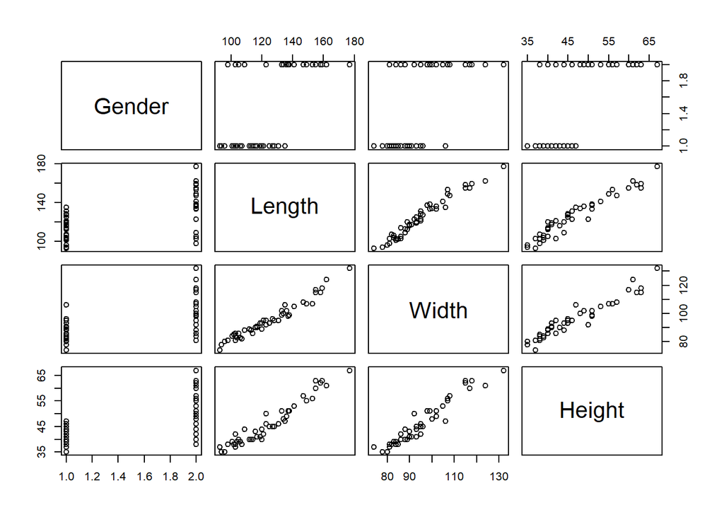

```r
plot(turtles)
```

The plot() function plots one vector vs another and plots the points in a chart.

### Question 2

**(a)**

```r
X1 = turtles$Length
X2 = turtles$Width
X3 = turtles$Height
X = cbind(X1,X2,X3)
```

**(b)** The first three lines of the R code assigns three different variables to each of the three columns creating three different vectors.

**(c)** The last line of code combines the three different vectors by columns. The dimensions of the vectors must also be of the same length.

### Question 3

**(a)**

```r
library(mvnormtest)
 mshapiro.test(t(X))
```

```
##
##  Shapiro-Wilk normality test
##
## data:  Z
## W = 0.90607, p-value = 0.000993
```

**(b)** This code chunk tests for normality. And it uses the Shapiro-Wilk test to check for multivariate normality. The function mshapiro.test() must take in a data frame of numeric values to perform the test.

**(c)** Using this test for normality we have p-value = $9.929809\times 10^{-4}$. This indicates that one or more variables are not normaly distrivuted, therefore multivariate normality does not hold.

**(d)** Yes. This t() is a function which will transpose our data frame. This is necessary so that our observations are in a column and the variables of those observations are in rows. This is necessary for the mshapiro.test() function to work.

### Question 4

**(a)**

```r
X.SM = apply(X,MARGIN = 2, FUN = mean)
X.SM
```

```
##        X1        X2        X3
## 124.68750  95.43750  46.33333
```

**(b)** This code chunk will apply the mean function and return the mean of each column in X.

### Question 5

**(a)**

```r
M.VC = var(X)
M.VC
```

```
##          X1       X2        X3
## X1 419.4960 253.9907 165.82979
## X2 253.9907 160.6769 102.19149
## X3 165.8298 102.1915  70.43972
```

```r
M.VC = cov(X)
M.VC
```

```
##          X1       X2        X3
## X1 419.4960 253.9907 165.82979
## X2 253.9907 160.6769 102.19149
## X3 165.8298 102.1915  70.43972
```

```r
det(M.VC)
```

```
## [1] 12790.67
```

```r
M.VC = cor(X)
M.VC
```

```
##           X1        X2        X3
## X1 1.0000000 0.9783116 0.9646946
## X2 0.9783116 1.0000000 0.9605705
## X3 0.9646946 0.9605705 1.0000000
```

**(b)** The first chunk of code calculates the variance of the data. The second chunk of code calculates the covariance of our data.

**(c)** The third chunk of code calculates the determinat of the data. The determinant of our data is $12790.67$. Which is a positive value greater than $0$ and tells us we have a nonsingular matrix. Therefore we can proceed with our multivariate statistical analysis.

**(d)** The fourth code chunk calculates the correlation matrix of our data. In the first and second code chunks we have the same matrix. For the third chunk the correlation matrix, we have positive values with $1$ on our diagonals which indicate a positive relationship between variables.

### Question 6

```r
library(biotools)
data(turtles)
factor(turtles[,1])
```

```
##  [1] Male   Male   Male   Male   Male   Male   Male   Male   Male   Male
## [11] Male   Male   Male   Male   Male   Male   Male   Male   Male   Male
## [21] Male   Male   Male   Male   Female Female Female Female Female Female
## [31] Female Female Female Female Female Female Female Female Female Female
## [41] Female Female Female Female Female Female Female Female
## Levels: Male Female
```

```r
boxM(turtles[,-1],turtles[,1])
```

```
##
##  Box's M-test for Homogeneity of Covariance Matrices
##
## data:  turtles[, -1]
## Chi-Sq (approx.) = 24.037, df = 6, p-value = 0.0005141
```

**(a)** The code chunk use the Box M Test which tests the equality of matrices between groups. It will specifically test for equality between variance and covariance matrices.

### Question 7

**(a)**

```r
#install.packages("ICSNP")
library(ICSNP)
hypvedatact = c(149,100,53)
test = HotellingsT2(X,mu=hypvedatact,test="f")
print(test)
```

```
##
##  Hotelling's one sample T2-test
##
## data:  X
## T.2 = 251.2, df1 = 3, df2 = 45, p-value < 2.2e-16
## alternative hypothesis: true location is not equal to c(149,100,53)
```

**(b)** The code uses a one sample T2 test and especifically is the two group (dependent) variable mean difference test. The test also uses the F-Distribution for the Hotellings T2 test. Running the code we get $T.2 = 251.2$ and $p-value = 2.2*e^{-16}$. This shows that our mean difference is statistically significant in our data.

### Question 8

**(a)**

```r
#install.packages("ICSNP")
library(ICSNP)
library(dplyr)
HotellingsT2(filter(turtles,Gender=="Male")[,2:4],filter(turtles,Gender=="Female")[,2:4])
```

```
##
##  Hotelling's two sample T2-test
##
## data:  filter(turtles, Gender == "Male")[, 2:4] and filter(turtles, Gender == "Female")[, 2:4]
## T.2 = 21.284, df1 = 3, df2 = 44, p-value = 1.141e-08
## alternative hypothesis: true location difference is not equal to c(0,0,0)
```